# Overview statistic tests PB

Author

Jonas van Nijnatten

contact: J.J.vanNijnatten@uva.nl

source code: https://github.com/jonasvannijnatten/PB_statistiek

laatste update: 19-03-2026

Other R manuals for Psychobiology: https://jonasvannijnatten.github.io/PB_statistiek/

# 1 R and package versions

## 1.1 Versions

software versions used for this tutorial:

| package | version |
| --- | --- |
| R | 4.5.1 (2025-06-13 ucrt) |
| knitr | 1.50 |
| kableExtra | 1.4.0 |
| car | 3.1.3 |
| ez | 4.4.0 |
| afex | 1.4.1 |
| ggplot2 | 3.5.2 |
| gridExtra | 2.3 |
| lmerTest | 3.2.1 |
| interactions | 1.2.0 |
| tidyverse | 2.0.0 |
| performance | 0.15.0 |
| emmeans | 1.11.2 |
| lmeresampler | 0.2.4 |

# 2 T-test

## 2.1 Independent samples T-test

**Show code for data generation**

```r
# generate data
N = 40
data.long = data.frame(
  ID = 1:N,
  condition = rep(x = c("A","B"), each = N),
  score = c(rnorm(n = N, mean = 25, sd = 6.5), rnorm(n = N, mean = 35, sd = 6.5))
)
```

data.long

| ID | condition | score |
| --- | --- | --- |
| 1 | A | 24.38840 |
| 2 | A | 23.50981 |
| 3 | A | 35.27920 |
| 4 | A | 45.59097 |
| 5 | A | 39.07399 |
| 1 | B | 30.18142 |
| 2 | B | 27.15098 |
| 3 | B | 44.45480 |
| 4 | B | 27.77554 |
| 5 | B | 29.59740 |

Test assumption of normality

```r
by(data = data.long$score, INDICES = data.long$condition, FUN = shapiro.test)
```

```
data.long$condition: A

    Shapiro-Wilk normality test

data:  dd[x, ]
W = 0.94817, p-value = 0.0656

------------------------------------------------------------
data.long$condition: B

    Shapiro-Wilk normality test

data:  dd[x, ]
W = 0.95875, p-value = 0.1518
```

Test assumption of equality of variances

```r
leveneTest(y = data.long$score, group = data.long$condition)
```

```
Levene's Test for Homogeneity of Variance (center = median)
      Df F value Pr(>F)
group  1  0.2314 0.6318
      78
```

**T-test**

```r
summary(lm(formula = score ~ condition, data = data.long))
t.test(formula = score ~ condition, data = data.long, alternative="two.sided", var.equal=TRUE)
```

```
Call:
lm(formula = score ~ condition, data = data.long)

Residuals:
     Min       1Q   Median       3Q      Max
-11.9323  -4.5684   0.0753   3.5994  21.2994

Coefficients:
            Estimate Std. Error t value Pr(>|t|)
(Intercept)  24.2916     0.9972  24.360   <2e-16 ***
conditionB   10.3102     1.4102   7.311    2e-10 ***
---
Signif. codes:  0 '***' 0.001 '**' 0.01 '*' 0.05 '.' 0.1 ' ' 1

Residual standard error: 6.307 on 78 degrees of freedom
Multiple R-squared:  0.4066,    Adjusted R-squared:  0.399
F-statistic: 53.45 on 1 and 78 DF,  p-value: 2.005e-10


    Two Sample t-test

data:  score by condition
t = -7.3111, df = 78, p-value = 2.005e-10
alternative hypothesis: true difference in means between group A and group B is not equal to 0
95 percent confidence interval:
 -13.117746  -7.502684
sample estimates:
mean in group A mean in group B
       24.29159        34.60181
```

## 2.2 Paired samples T-test

**Show code for data generation**

```r
# generate data
N = 30
data.long = data.frame(
  ID = rep(1:N,2),
  condition = rep(x = c("A","B"), each = N),
  score = c(rnorm(n = N, mean = 25, sd = 6.5), rnorm(n = N, mean = 35, sd = 6.5))
)
data.wide = pivot_wider(data.long, id_cols = ID, names_from = condition, values_from = score)
```

**t.test method**

data.wide

| ID | A | B |
| --- | --- | --- |
| 1 | 39.49128 | 30.10550 |
| 2 | 23.75357 | 41.76641 |
| 3 | 23.71405 | 22.27914 |
| 4 | 32.49847 | 47.09713 |
| 5 | 26.04856 | 27.75161 |
| 6 | 29.55946 | 30.10921 |
| 7 | 30.27512 | 32.35638 |
| 8 | 21.22922 | 36.26641 |
| 9 | 22.78279 | 26.58692 |
| 10 | 12.55242 | 35.42104 |

**Test assumption of normality**

```r
# calculate difference scores
diffScore = data.long$score[data.long$condition=="A"] - data.long$score[data.long$condition=="B"]
shapiro.test(diffScore)
```

```
    Shapiro-Wilk normality test

data:  diffScore
W = 0.97314, p-value = 0.6282
```

**T-test**

```r
t.test(data.wide$A, data.wide$B, alternative = "two.sided", paired = TRUE)
```

```
    Paired t-test

data:  data.wide$A and data.wide$B
t = -3.9035, df = 29, p-value = 0.0005195
alternative hypothesis: true mean difference is not equal to 0
95 percent confidence interval:
 -9.565012 -2.987967
sample estimates:
mean difference
      -6.276489
```

**lmer method**

data.long

| ID | condition | score |
| --- | --- | --- |
| 1 | A | 39.49128 |
| 2 | A | 23.75357 |
| 3 | A | 23.71405 |
| 4 | A | 32.49847 |
| 5 | A | 26.04856 |
| 1 | B | 30.10550 |
| 2 | B | 41.76641 |
| 3 | B | 22.27914 |
| 4 | B | 47.09713 |
| 5 | B | 27.75161 |

**Fit the model**

```r
model = lmer(formula = score ~ condition+(1|ID), data = data.long)
```

**Check the assumptions**

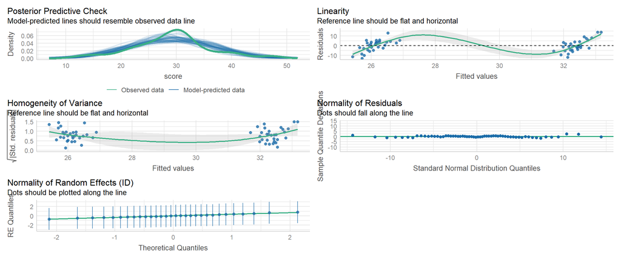

```r
check_model(model)
```

**Test the model**

```r
summary(model)$coefficients
```

```
             Estimate Std. Error       df   t value     Pr(>|t|)
(Intercept) 26.103042   1.159548 57.91377 22.511400 2.526162e-30
conditionB   6.276489   1.607899 29.00000  3.903535 5.195355e-04
```

# 3 Correlation

**Show code for data generation**

```r
# generate data
set.seed(05)
nrobs = 100
experience = rnorm(n = nrobs, mean = 15, sd = 3)
salary     = 10000 + ( 5 * experience ) + rnorm(n = nrobs, mean = 0, sd = 100)
data.long = data.frame(experience, salary)
# calculate correlation coefficient r
corr_coef = cor(x = data.long$experience, y = data.long$salary)
rm(list = c("nrobs", "experience", "salary"))
```

data.long

| experience | salary |
| --- | --- |
| 12.47743 | 9862.848 |
| 19.15308 | 10209.297 |
| 11.23352 | 10123.747 |
| 15.21043 | 10096.900 |
| 20.13432 | 10094.887 |

Test assumption of normality

```r
apply(X = data.long, MARGIN = 2, FUN = shapiro.test)
```

```
$experience

    Shapiro-Wilk normality test

data:  newX[, i]
W = 0.98711, p-value = 0.445


$salary

    Shapiro-Wilk normality test

data:  newX[, i]
W = 0.99257, p-value = 0.8607
```

**Pearson correlation**

```r
cor.test(x=data.long$experience, y=data.long$salary, alternative = "two.sided", method = "pearson")
```

```
    Pearson's product-moment correlation

data:  data.long$experience and data.long$salary
t = 2.5509, df = 98, p-value = 0.01229
alternative hypothesis: true correlation is not equal to 0
95 percent confidence interval:
 0.05584335 0.42510763
sample estimates:
      cor
0.2495245
```

**Spearman correlation**

```r
cor.test(x=data.long$experience, y=data.long$salary, alternative = "two.sided", method = "spearman")
```

```
    Spearman's rank correlation rho

data:  data.long$experience and data.long$salary
S = 121190, p-value = 0.006181
alternative hypothesis: true rho is not equal to 0
sample estimates:
      rho
0.2727873
```

# 4 Regression

**Show code for data generation**

```r
# generate data
set.seed(05)
nrobs = 100
experience = rnorm(n = nrobs, mean = 15, sd = 3)
salary     = 10000 + ( 5 * experience ) + rnorm(n = nrobs, mean = 0, sd = 100)
data.long = data.frame(experience, salary)
# calculate correlation coefficient r
corr_coef = cor(x = data.long$experience, y = data.long$salary)
rm(list = c("nrobs", "experience", "salary"))
```

data.long

| experience | salary |
| --- | --- |
| 12.47743 | 9862.848 |
| 19.15308 | 10209.297 |
| 11.23352 | 10123.747 |
| 15.21043 | 10096.900 |
| 20.13432 | 10094.887 |

Fit linear model

```r
linearModel = lm(formula = salary ~ experience, data = data.long)
```

Test assumption of normality & equal variances

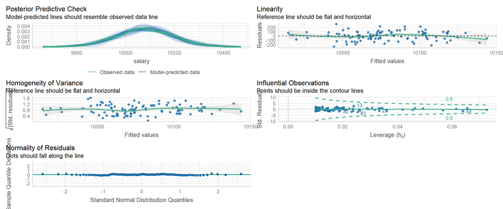

```r
check_model(linearModel)
```

**Regression test**

```r
summary(linearModel)
```

```
Call:
lm(formula = salary ~ experience, data = data.long)

Residuals:
    Min      1Q  Median      3Q     Max
-248.24  -61.55   10.13   74.34  273.17

Coefficients:
            Estimate Std. Error t value Pr(>|t|)
(Intercept) 9934.674     56.812 174.870   <2e-16 ***
experience     9.437      3.700   2.551   0.0123 *
---
Signif. codes:  0 '***' 0.001 '**' 0.01 '*' 0.05 '.' 0.1 ' ' 1

Residual standard error: 104.4 on 98 degrees of freedom
Multiple R-squared:  0.06226,   Adjusted R-squared:  0.05269
F-statistic: 6.507 on 1 and 98 DF,  p-value: 0.01229
```

# 5 Logistic regression

**Show code for data generation**

```r
set.seed(01)
N = 30
x = sort(runif(n = N, min = 0, max = 10))
y = round(
  1 / (1 + exp(-.5*x+(max(x)/4) + rnorm(N,0,1.5)))  # logistic function of x + noise
  ) # round it to either 1 or 0
data.long = data.frame(x = x, y = y)
```

```r
# fit a logistic model, which is a generalized linear model, hence glm() function
glm.fit <- glm(y ~ x, data = data.long, family = binomial('logit'))
# test the logistic model against the NULL model
summary(glm.fit)
```

```
Call:
glm(formula = y ~ x, family = binomial("logit"), data = data.long)

Coefficients:
            Estimate Std. Error z value Pr(>|z|)
(Intercept)  -3.8011     1.3435  -2.829  0.00467 **
x             0.8192     0.2728   3.003  0.00268 **
---
Signif. codes:  0 '***' 0.001 '**' 0.01 '*' 0.05 '.' 0.1 ' ' 1

(Dispersion parameter for binomial family taken to be 1)

    Null deviance: 41.455  on 29  degrees of freedom
Residual deviance: 22.266  on 28  degrees of freedom
AIC: 26.266

Number of Fisher Scoring iterations: 5
```

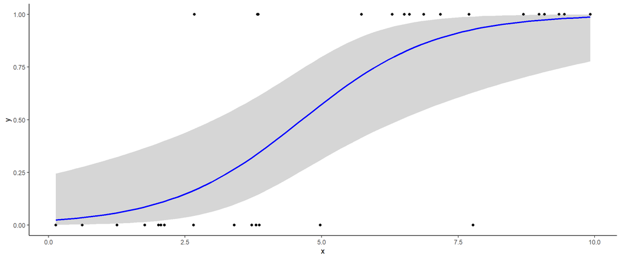

```r
ggplot(data.long, aes(x=x, y=y)) + geom_point() +
  stat_smooth(method="glm", color="blue", se=TRUE,
              method.args = list(family=binomial)) +
  theme_classic()
```

# 6 One-way independent samples ANOVA

**Toon code om voorbeeld data te genereren**

```r
set.seed(05)   # set seed
nrofconds = 3  # set number of conditions
nrofsubs  = 20 # set number of subjects
subj = as.factor(1:(nrofsubs*nrofconds))      # create array with subject IDs
condition = as.factor(rep(LETTERS[1:nrofconds],each=nrofsubs))   # create array with condition values
score = as.vector( replicate(
          nrofconds , rnorm(n = nrofsubs, mean = sample(8,1)+10 , sd = sample(5,1) )
        ) )                                     # create array with measurement values
data.long = data.frame(subj, condition, score);      # combine arrays into a data.frame
rm(list=c("subj", "condition","score","nrofconds","nrofsubs")) # delete unnecessary variables
```

data.long

| subj | condition | score |
| --- | --- | --- |
| 1 | A | 16.153078 |
| 2 | A | 8.233524 |
| 21 | B | 18.935924 |
| 22 | B | 17.413522 |
| 41 | C | 15.895668 |
| 42 | C | 13.543431 |

## 6.1 Running the test

**parametric methods**

**using lm() (PB recommended)**

*ANOVA* using the linear model method

Fit the model using *lm()*.

```r
lmModel = lm(formula = score ~ condition, data = data.long)
```

Check the assumptions using *performance::check_model()*

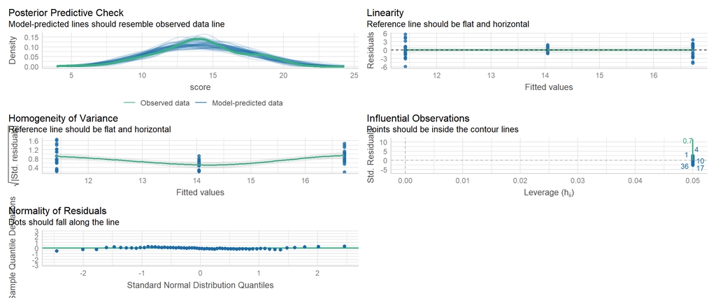

```r
check_model(lmModel)
```

To get the results of the hypothesis test, use the anova() function

```r
anova(lmModel)
```

```
Analysis of Variance Table

Response: score
          Df Sum Sq Mean Sq F value    Pr(>F)
condition  2 281.27 140.637  28.425 2.734e-09 ***
Residuals 57 282.01   4.948
---
Signif. codes:  0 '***' 0.001 '**' 0.01 '*' 0.05 '.' 0.1 ' ' 1
```

Post-hoc testing When using the linear model method, use pairwise t-test or emmeans() from the emmeans package.

```r
pairwise.t.test(x = data.long$score, g = data.long$condition, paired = FALSE, p.adjust.method = "bonferroni")

# for post hoc comparison of conditions using the emmeans() function from the emmeans package
emmeans(lmModel, pairwise~condition, )
```

```
    Pairwise comparisons using t tests with pooled SD

data:  data.long$score and data.long$condition

  A       B
B 1.2e-09 -
C 0.0013  0.0010

P value adjustment method: bonferroni
$emmeans
 condition emmean    SE df lower.CL upper.CL
 A           11.4 0.497 57     10.4     12.4
 B           16.7 0.497 57     15.7     17.7
 C           14.0 0.497 57     13.0     15.0

Confidence level used: 0.95

$contrasts
 contrast estimate    SE df t.ratio p.value
 A - B       -5.30 0.703 57  -7.540  <.0001
 A - C       -2.62 0.703 57  -3.729  0.0013
 B - C        2.68 0.703 57   3.810  0.0010

P value adjustment: tukey method for comparing a family of 3 estimates
```

**using ezANOVA()**

*ANOVA* using the ezANOVA method

Test assumption of normality

```r
by(data = data.long$score, INDICES = data.long$condition, FUN = shapiro.test)
```

```
data.long$condition: A

    Shapiro-Wilk normality test

data:  dd[x, ]
W = 0.9637, p-value = 0.6201

------------------------------------------------------------
data.long$condition: B

    Shapiro-Wilk normality test

data:  dd[x, ]
W = 0.92868, p-value = 0.1456

------------------------------------------------------------
data.long$condition: C

    Shapiro-Wilk normality test

data:  dd[x, ]
W = 0.94927, p-value = 0.3561
```

Test equality of variances

```r
leveneTest(y = data.long$score, group = data.long$condition)
```

```
Levene's Test for Homogeneity of Variance (center = median)
      Df F value   Pr(>F)
group  2  6.6526 0.002531 **
      57
---
Signif. codes:  0 '***' 0.001 '**' 0.01 '*' 0.05 '.' 0.1 ' ' 1
```

```r
ezModel = ezANOVA(data = data.long, dv = score, between = condition, wid = subj)
ezModel$ANOVA
```

```
     Effect DFn DFd        F            p p<.05       ges
1 condition   2  57 28.42547 2.734255e-09     * 0.4993454
```

**using aov_ez()**

*ANOVA* using the aov_ez() method 1. First we build the model using the *aov_ez()* function from the *afex* package.

```r
afexModel = aov_ez(data = data.long, id = "subj", dv = "score", between = "condition")
afexModel$anova_table
```

```
Anova Table (Type 3 tests)

Response: score
          num Df den Df    MSE      F     ges    Pr(>F)
condition      2     57 4.9476 28.425 0.49935 2.734e-09 ***
---
Signif. codes:  0 '***' 0.001 '**' 0.01 '*' 0.05 '.' 0.1 ' ' 1
```

2. Next we test the assumption of normality for all the residuals in the model at once:

```
    Shapiro-Wilk normality test

data:  afexModel$lm$residuals
W = 0.98581, p-value = 0.7121
```

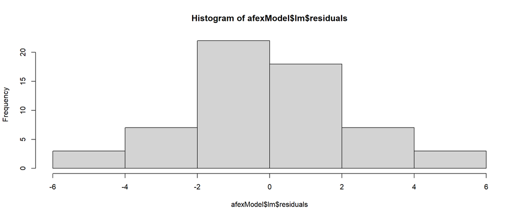

```r
hist(afexModel$lm$residuals)
shapiro.test(afexModel$lm$residuals)
```

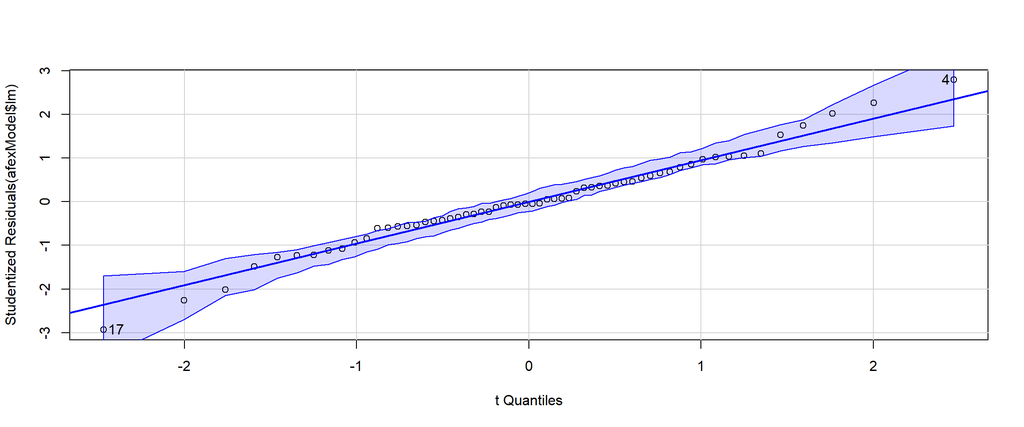

```r
# library(car)
qqPlot(afexModel$lm)
```

3. Then we test the assumption of equal variences using Levene’s Test:

```r
leveneTest(afexModel$lm)
```

```
Levene's Test for Homogeneity of Variance (center = median)
      Df F value   Pr(>F)
group  2  6.6526 0.002531 **
      57
---
Signif. codes:  0 '***' 0.001 '**' 0.01 '*' 0.05 '.' 0.1 ' ' 1
```

**using aov()**

*ANOVA* using the aov method

Test assumption of normality

```r
by(data = data.long$score, INDICES = data.long$condition, FUN = shapiro.test)
```

```
data.long$condition: A

    Shapiro-Wilk normality test

data:  dd[x, ]
W = 0.9637, p-value = 0.6201

------------------------------------------------------------
data.long$condition: B

    Shapiro-Wilk normality test

data:  dd[x, ]
W = 0.92868, p-value = 0.1456

------------------------------------------------------------
data.long$condition: C

    Shapiro-Wilk normality test

data:  dd[x, ]
W = 0.94927, p-value = 0.3561
```

Test equality of variances

```r
leveneTest(y = data.long$score, group = data.long$condition)
```

```
Levene's Test for Homogeneity of Variance (center = median)
      Df F value   Pr(>F)
group  2  6.6526 0.002531 **
      57
---
Signif. codes:  0 '***' 0.001 '**' 0.01 '*' 0.05 '.' 0.1 ' ' 1
```

Run the ANOVA and check the results

```r
aovModel = aov(formula = score ~ condition, data = data.long)
summary(aovModel)
```

```
            Df Sum Sq Mean Sq F value   Pr(>F)
condition    2  281.3  140.64   28.43 2.73e-09 ***
Residuals   57  282.0    4.95
---
Signif. codes:  0 '***' 0.001 '**' 0.01 '*' 0.05 '.' 0.1 ' ' 1
```

When using the aov method, use the Tukey post-hoc test

```r
TukeyHSD(aovModel)
```

```
  Tukey multiple comparisons of means
    95% family-wise confidence level

Fit: aov(formula = score ~ condition, data = data.long)

$condition
         diff        lwr        upr     p adj
B-A  5.303422  3.6107737  6.9960712 0.0000000
C-A  2.623183  0.9305343  4.3158318 0.0012725
C-B -2.680239 -4.3728882 -0.9875907 0.0009846
```

**Non-parametric methods**

```r
kruskal.test(score~condition, data.long)
```

```
    Kruskal-Wallis rank sum test

data:  score by condition
Kruskal-Wallis chi-squared = 28.542, df = 2, p-value = 6.343e-07
```

# 7 Factorial independent samples ANOVA

**Show code for data generation**

```r
set.seed(01)   # set seed
nrofcondsf1 = 3  # set number of conditions for factor 1
nrofcondsf2 = 2  # set number of conditions for factor 2
nrofsubs    = nrofcondsf1*nrofcondsf2*30 # set number of subjects per condition
subj = as.factor(1:(nrofsubs))      # create array with subject IDs
# create array witht treatment conditions
treatment = as.factor(rep(LETTERS[1:nrofcondsf1],each=nrofsubs/nrofcondsf1))
# create array with control / experimental
control   = as.factor(rep(c("control","experimental"),times=nrofsubs/nrofcondsf2))
# create array with measurement values
score = as.vector( replicate(nrofcondsf1, replicate (
          nrofcondsf2 , rnorm(
            n = (nrofsubs/(nrofcondsf1*nrofcondsf2)),
            mean = 0 , sd = sample(5,1) ) + sample(8,1)+10
        ) ) )
# combine arrays into a data.frame
data.long = data.frame(subj, score, treatment, control);
# delete unnecessary arrays
rm(list=c("control","nrofcondsf1","nrofcondsf2","nrofsubs","score","subj","treatment"))
```

data.long

| subj | score | treatment | control |
| --- | --- | --- | --- |
| 1 | 11.673767 | A | control |
| 2 | 13.329799 | A | experimental |
| 61 | 13.484527 | B | control |
| 62 | 10.149803 | B | experimental |
| 121 | 10.811829 | C | control |
| 122 | 7.591698 | C | experimental |

## 7.1 Fitting the model

Fit model with multiple prediction factors

```r
model = lm(formula = score ~ treatment+control, data = data.long)
```

## 7.2 Checking assumptions

Visually inspect all assumptions using the *check_model()* function from the *performance* package.

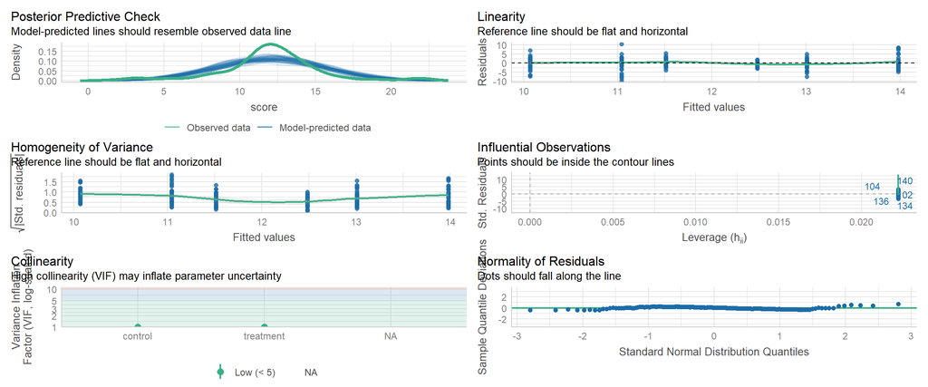

```r
check_model(model)
```

## 7.3 Running the test

ANOVA with the linear model method

```r
model = lm(formula = score ~ treatment*control, data = data.long)
library(car)
Anova(mod = model, type = 'II')
summary(model)
```

```
Anova Table (Type II tests)

Response: score
                   Sum Sq  Df F value    Pr(>F)
treatment          258.86   2 13.9977 2.307e-06 ***
control             42.48   1  4.5938   0.03348 *
treatment:control   68.54   2  3.7065   0.02652 *
Residuals         1608.91 174
---
Signif. codes:  0 '***' 0.001 '**' 0.01 '*' 0.05 '.' 0.1 ' ' 1

Call:
lm(formula = score ~ treatment * control, data = data.long)

Residuals:
    Min      1Q  Median      3Q     Max
-9.4199 -1.3624  0.2495  1.4918 10.5877

Coefficients:
                               Estimate Std. Error t value Pr(>|t|)
(Intercept)                    12.15286    0.55518  21.890  < 2e-16 ***
treatmentB                      0.02103    0.78514   0.027  0.97866
treatmentC                     -1.88866    0.78514  -2.406  0.01720 *
controlexperimental            -0.30843    0.78514  -0.393  0.69492
treatmentB:controlexperimental  2.94763    1.11035   2.655  0.00867 **
treatmentC:controlexperimental  0.89236    1.11035   0.804  0.42268
---
Signif. codes:  0 '***' 0.001 '**' 0.01 '*' 0.05 '.' 0.1 ' ' 1

Residual standard error: 3.041 on 174 degrees of freedom
Multiple R-squared:  0.1869,    Adjusted R-squared:  0.1636
F-statistic:     8 on 5 and 174 DF,  p-value: 8.234e-07
```

## 7.4 Post-hoc analysis

**Using the estimated marginal means (emmeans)**

When there are one or more significant main-effects but no significant interaction effect post-hoc comparisons can be made for each factor separately using the emmeans() function.

#### 7.4.0.1 Post-hoc inspection of the main effect of the factor *treatment*.

```r
emmeans(model, pairwise ~ treatment)
```

```
$emmeans
 treatment emmean    SE  df lower.CL upper.CL
 A           12.0 0.393 174    11.22     12.8
 B           13.5 0.393 174    12.72     14.3
 C           10.6 0.393 174     9.78     11.3

Results are averaged over the levels of: control
Confidence level used: 0.95

$contrasts
 contrast estimate    SE  df t.ratio p.value
 A - B       -1.49 0.555 174  -2.693  0.0211
 A - C        1.44 0.555 174   2.598  0.0273
 B - C        2.94 0.555 174   5.291  <.0001

Results are averaged over the levels of: control
P value adjustment: tukey method for comparing a family of 3 estimates
```

#### 7.4.0.2 Post-hoc inspection of the main effect of the factor *control*.

```r
emmeans(model, pairwise ~ control)
```

```
$emmeans
 control      emmean    SE  df lower.CL upper.CL
 control        11.5 0.321 174     10.9     12.2
 experimental   12.5 0.321 174     11.9     13.1

Results are averaged over the levels of: treatment
Confidence level used: 0.95

$contrasts
 contrast               estimate    SE  df t.ratio p.value
 control - experimental   -0.972 0.453 174  -2.143  0.0335

Results are averaged over the levels of: treatment
```

#### 7.4.0.3 Post-hoc inspection of the interaction effect

```r
emmeans(model, pairwise ~ treatment + control)
```

```
$emmeans
 treatment control      emmean    SE  df lower.CL upper.CL
 A         control        12.2 0.555 174    11.06     13.2
 B         control        12.2 0.555 174    11.08     13.3
 C         control        10.3 0.555 174     9.17     11.4
 A         experimental   11.8 0.555 174    10.75     12.9
 B         experimental   14.8 0.555 174    13.72     15.9
 C         experimental   10.8 0.555 174     9.75     11.9

Confidence level used: 0.95

$contrasts
 contrast                        estimate    SE  df t.ratio p.value
 A control - B control             -0.021 0.785 174  -0.027  1.0000
 A control - C control              1.889 0.785 174   2.406  0.1600
 A control - A experimental         0.308 0.785 174   0.393  0.9988
 A control - B experimental        -2.660 0.785 174  -3.388  0.0111
 A control - C experimental         1.305 0.785 174   1.662  0.5589
 B control - C control              1.910 0.785 174   2.432  0.1510
 B control - A experimental         0.329 0.785 174   0.420  0.9983
 B control - B experimental        -2.639 0.785 174  -3.361  0.0121
 B control - C experimental         1.326 0.785 174   1.689  0.5412
 C control - A experimental        -1.580 0.785 174  -2.013  0.3394
 C control - B experimental        -4.549 0.785 174  -5.794  <.0001
 C control - C experimental        -0.584 0.785 174  -0.744  0.9761
 A experimental - B experimental   -2.969 0.785 174  -3.781  0.0029
 A experimental - C experimental    0.996 0.785 174   1.269  0.8015
 B experimental - C experimental    3.965 0.785 174   5.050  <.0001

P value adjustment: tukey method for comparing a family of 6 estimates
```

**Using pairwise T-tests**

When there are one or more significant main-effects but no significant interaction effect post-hoc comparisons can be made for each factor separately using the pairwise.t.test() function.

#### 7.4.0.4 Post-hoc comparison for the first factor

```r
pairwise.t.test(
  x = data.long$score               # column name of the dependent variable
  ,g = data.long$treatment          # column name of the first within-subjects variable
  , paired = FALSE                   # since it is a paired design, set paired=TRUE
  , p.adjust.method = "bonferroni"  # use bonferroni corrected p-values
  )
```

```
    Pairwise comparisons using t tests with pooled SD

data:  data.long$score and data.long$treatment

  A     B
B 0.028 -
C 0.036 2e-06

P value adjustment method: bonferroni
```

#### 7.4.0.5 Post-hoc comparison for the second factor

```r
pairwise.t.test(
  x = data.long$score               # column name of the dependent variable
  ,g = data.long$control           # column name of the second within-subjects variable
  , paired = FALSE                   # since it is a paired design, set paired=TRUE
  , p.adjust.method = "bonferroni"  # use bonferroni corrected p-values
  )
```

```
    Pairwise comparisons using t tests with pooled SD

data:  data.long$score and data.long$control

             control
experimental 0.05

P value adjustment method: bonferroni
```

#### 7.4.0.6 Post-hoc comparison for the interaction effect

When the interaction effect turns out significant, pairwise comparisons can be made between all combinations of conditions.

```r
pairwise.t.test(
  x = data.long$score               # column name of the dependent variable
  # merge both factor columns into a combined factor
  ,g = paste(data.long$treatment, data.long$control)
  , paired = FALSE                   # since it is a paired design, set paired=TRUE
  , p.adjust.method = "bonferroni"  # use bonferroni corrected p-values
  )
```

```
    Pairwise comparisons using t tests with pooled SD

data:  data.long$score and paste(data.long$treatment, data.long$control)

               A control A experimental B control B experimental C control
A experimental 1.0000    -              -         -              -
B control      1.0000    1.0000         -         -              -
B experimental 0.0131    0.0032         0.0143    -              -
C control      0.2580    0.6854         0.2402    4.7e-07        -
C experimental 1.0000    1.0000         1.0000    1.7e-05        1.0000

P value adjustment method: bonferroni
```

## 7.5 Visualisation

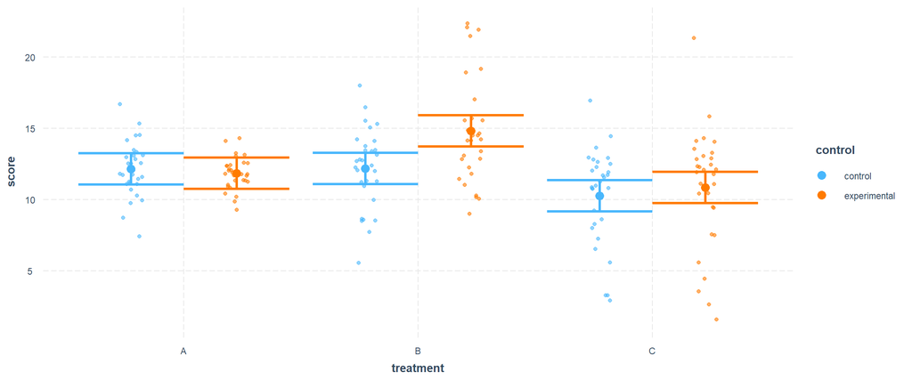

```r
cat_plot(model = model,   # which model to plot
         pred = treatment,  # variable to plot on the x-axis
         modx = control,    # categorical variable for which to plot seperate colors
         interval = TRUE,  # logical whether to display a confidence interval
         plot.points = TRUE, # logical whether to plot individual data points
         jitter = 0.2) # add jitter (prevents overlapping data point in plot)
```

# 8 One-way repeated measures ANOVA

**Show code for data generation**

```r
# Generate dataset
set.seed(01)   # set seed
nrofsubs  = 20 # set number of subjects
data.wide = data.frame(
  subj = as.factor(1:nrofsubs)   ,
  A =  rnorm(n = nrofsubs, mean = sample(8,1)+10 , sd = sample(5,1)) ,
  B =  rnorm(n = nrofsubs, mean = sample(8,1)+10 , sd = sample(5,1)) ,
  C =  rnorm(n = nrofsubs, mean = sample(8,1)+10 , sd = sample(5,1))
)
rm(list=c("nrofsubs")) # delete arrays

# reshape the data to the long format for some analysis methods
data.long = reshape(
  data = data.wide
  ,direction  = 'long'          # richting van de data-transformatie
  ,varying    = c('A','B','C')  # kolomnamen die worden samengevoegd
  ,idvar      = 'subj'          # kolomnaam met de ppn-nummers
  ,v.names    = 'score'         # naam van nieuwe kolom met meetwaarden
  ,timevar    = 'condition'     # naam van nieuwe kolom met condities
  ,times      = c('A','B','C')  # waardes
  )
data.long$condition = as.factor(data.long$condition)
```

data.wide

| subj | A | B | C |
| --- | --- | --- | --- |
| 1 | 11.734573 | 17.298260 | 13.226653 |
| 2 | 7.657486 | 9.042593 | 8.244977 |
| 3 | 17.381123 | 19.479303 | 8.170019 |
| 4 | 12.318031 | 16.775485 | 12.458328 |

data.long

| subj | condition | score |
| --- | --- | --- |
| 1 | A | 11.734573 |
| 2 | A | 7.657486 |
| 1 | B | 17.298260 |
| 2 | B | 9.042593 |
| 1 | C | 13.226653 |
| 2 | C | 8.244977 |

## 8.1 Fitting the model

**Parametric Test**

**Using lmer() from lmerTest package**

First we fit the model using the *lmer()* function:

```r
model = lmer(
  formula = score~condition+(1|subj),
  data = data.long
  )
```

Visually inspect the assumptions using the *check_model()* function.

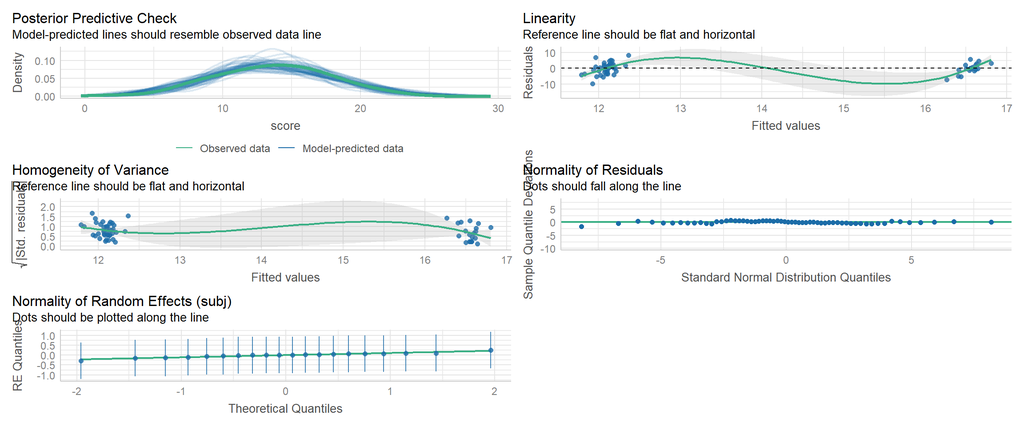

```r
check_model(model)
```

Get the inferential statistics of the model fit

```r
anova(model)
```

```
Type III Analysis of Variance Table with Satterthwaite's method
          Sum Sq Mean Sq NumDF DenDF F value    Pr(>F)
condition 265.22  132.61     2    38   10.61 0.0002183 ***
---
Signif. codes:  0 '***' 0.001 '**' 0.01 '*' 0.05 '.' 0.1 ' ' 1
```

**Using ezAONVA**

1. First we fit the model using the *ezANOVA()* function:

```r
ezModel = ezANOVA(data = data.long, dv = score, wid = subj, within = condition)
```

2. Then we check for the assumption of normality. Because the model takes into account individual differences, we should first correct the individual score by removing the individual differences from the data. We do this by calculating how each individual differes from the overall mean.

$corrected = Y_{i,j}corrected - (\overline{Yi} - \overline{Y})$

where $i$ represents the individual subjects, and $j$ represents the different conditions

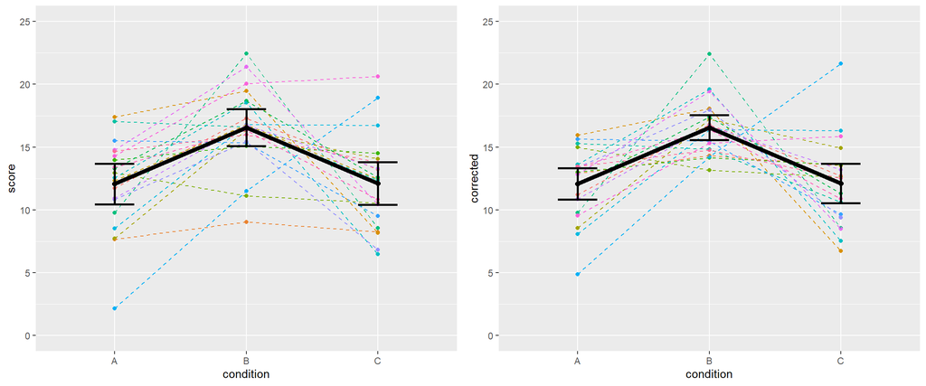

```r
# initialize variables to store calculate correted score
data.long$subjMean     = rep(NA, dim(data.long)[1])
data.long$correction   = rep(NA, dim(data.long)[1])
data.long$corrected    = rep(NA, dim(data.long)[1])

for (i in unique(data.long$subj)){
  # calculate the mean score for each subject (across conditions)
  data.long$subjMean[which(data.long$subj==i)] = mean(data.long$score[which(data.long$subj==i)])
  # calculate the correction as the difference between the subject mean vs the overall mean
  data.long$correction[which(data.long$subj==i)] =
    (data.long$subjMean[which(data.long$subj==i)] - mean(data.long$score))
  # calculate the corrected score by subtracting the correction per subject from each individual score value
  data.long$corrected[which(data.long$subj==i)] =
    data.long$score[which(data.long$subj==i)] - data.long$correction[which(data.long$subj==i)]
}


p1 = ggplot(data.long, aes(x=condition, y=score, group=1, colour=subj)) +
  geom_point   () +
  geom_line    ( linetype= "dashed", aes(group=subj) ) +
  stat_summary ( geom = "line",  fun    = "mean" ,    linewidth=2, colour="black", linetype="solid") +
  stat_summary ( geom = "point", fun    = "mean" ,    size=2, colour="black") +
  geom_errorbar( stat="summary", fun.data="mean_se",  linewidth=1, fun.args = 2, width = 0.3 ) +
  ylim(0, 25) +
  guides(color = "none")

p2 = ggplot(data.long, aes(x=condition, y=corrected, group=1, colour=subj)) +
  geom_point   () +
  geom_line    ( linetype= "dashed", aes(group=subj) ) +
  stat_summary ( geom = "line",  fun    = "mean" ,    linewidth=2, colour="black", linetype="solid") +
  stat_summary ( geom = "point", fun    = "mean" ,    size=2, colour="black") +
  geom_errorbar( stat="summary", fun.data="mean_se",  linewidth=1, fun.args = 2, width = 0.3 ) +
  ylim(0, 25) +
  guides(color = "none")

grid.arrange(p1, p2, nrow = 1)
```

Then we can use the corrected data to test for normality:

```r
by(data = data.long$corrected, INDICES = data.long$condition, FUN = shapiro.test)
par(mfrow=c(1,3))
by(data = data.long$corrected, INDICES = data.long$condition, FUN = hist)
par(mfrow=c(1,1))
```

```
data.long$condition: A

    Shapiro-Wilk normality test

data:  dd[x, ]
W = 0.93824, p-value = 0.2221

------------------------------------------------------------
data.long$condition: B

    Shapiro-Wilk normality test

data:  dd[x, ]
W = 0.94532, p-value = 0.3015

------------------------------------------------------------
data.long$condition: C

    Shapiro-Wilk normality test

data:  dd[x, ]
W = 0.9478, p-value = 0.3349
```

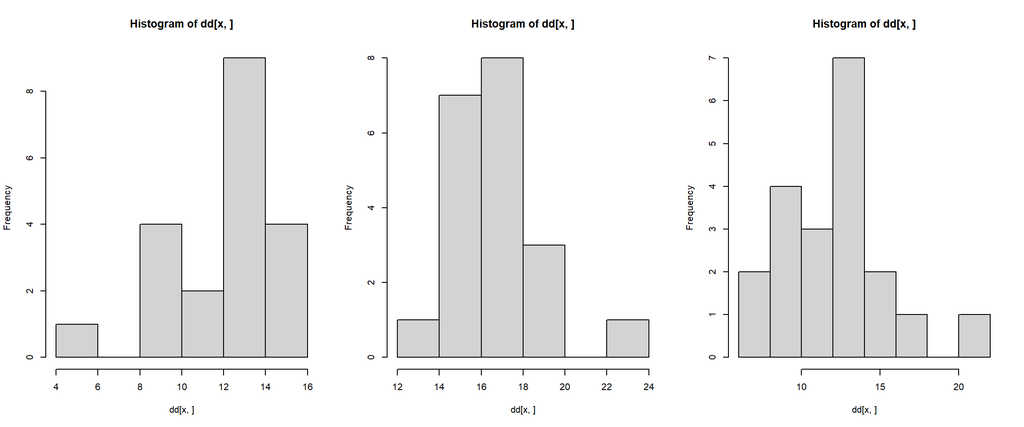

3. Then we check the assumption of spherecity using Mauchly’s test (which is built into the ezANOVA)

```r
ezModel$`Mauchly's Test for Sphericity`
```

```
     Effect         W          p p<.05
2 condition 0.7520886 0.07698763
```

If the assumption of spherecity is violated, you can use the corrected output of the *ezANOVA()* function. You don’ need te refer to a non-parametric alternative.

```r
ezModel$`Sphericity Corrections`
```

```
     Effect       GGe        p[GG] p[GG]<.05       HFe        p[HF] p[HF]<.05
2 condition 0.8013389 0.0006974823         * 0.8637409 0.0004837266         *
```

Otherwise we can use the default output as results:

```r
ezModel$ANOVA
```

```
     Effect DFn DFd        F            p p<.05       ges
2 condition   2  38 10.61008 0.0002182557     * 0.2675837
```

**Using aov_ez()**

1. First we fit the model using *aov_ez()*

```r
library(afex)
afexModel = aov_ez(id = "subj", dv = "score", data = data.long, within = "condition", )
```

2. Next we test the assumption of normality for all the residuals in the model at once:

```
    Shapiro-Wilk normality test

data:  afexModel$lm$residuals
W = 0.9868, p-value = 0.7629
```

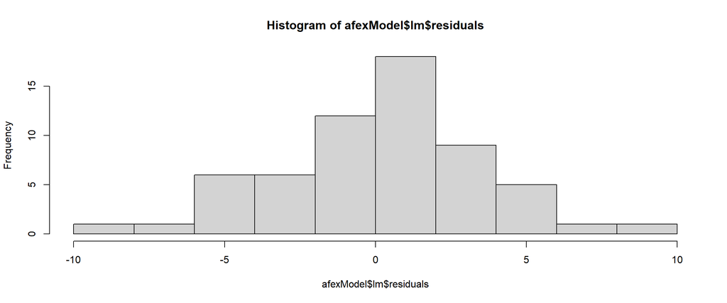

```r
hist(afexModel$lm$residuals)
shapiro.test(afexModel$lm$residuals)
```

4. The *aov_ez()* both calculates the ANOVA results and checks for the assumption of sphericity.

The function also automatically calculates two corrected p-values if the data deviate from sphericity; the Greenhouse-Geisser correction and the Huynh-Feldt correction. If the sphericity test is significant, use one of the corrected p-values (rule of thumb: when the Greenhouse-Geisser Epsilon (GG eps) is less than 0.75, use Greenhouse-Geisser correction [*Pr(>F[GG])*], else use the Huynh-Feldt correction [*Pr(>F(HF))*].

The degree of the correction depends on the degree of (non)-sphericity. So when the data is perfectly spherical, the correction is zero.

```r
summary(afexModel)
```

```
Univariate Type III Repeated-Measures ANOVA Assuming Sphericity

             Sum Sq num Df Error SS den Df F value    Pr(>F)
(Intercept) 11060.3      1   251.00     19  837.23 < 2.2e-16 ***
condition     265.2      2   474.93     38   10.61 0.0002183 ***
---
Signif. codes:  0 '***' 0.001 '**' 0.01 '*' 0.05 '.' 0.1 ' ' 1


Mauchly Tests for Sphericity

          Test statistic  p-value
condition        0.75209 0.076988


Greenhouse-Geisser and Huynh-Feldt Corrections
 for Departure from Sphericity

           GG eps Pr(>F[GG])
condition 0.80134  0.0006975 ***
---
Signif. codes:  0 '***' 0.001 '**' 0.01 '*' 0.05 '.' 0.1 ' ' 1

             HF eps   Pr(>F[HF])
condition 0.8637409 0.0004837266
```

**Non-parametric test**

When the assumptions of parametric testing are violated the Friedman ANOVA can be used: (Note: when the assumption of sphericity is violated you can still run an ANOVA and use the Greenhouse-Geisser corrected F- and p-value.)

```r
FMaov = friedman.test(score~condition|subj, data.long)
```

## 8.2 Post-hoc analysis

**parametric**

For post-hoc analysis the data has to be transformed to the **long format**

**Show code for reshaping**

```r
# reshape into wide format
data.long = reshape(data = data.wide
                   , direction = 'long'
                   , varying = c("A","B","C")
                   , timevar = 'treatment'
                   , times = c("A","B","C")
                   , v.names = c("score")
                   , idvar = "subj"
                   )
```

**Using emmeans**

Use the estimated marginal means (emmeans) for post-hoc analysis.

```r
ref.grid = ref_grid(model)
condition.emm = emmeans(ref.grid, "condition")
pairs(condition.emm, reverse = FALSE)
```

```
 contrast estimate   SE df t.ratio p.value
 A - B     -4.4791 1.12 38  -4.007  0.0008
 A - C     -0.0386 1.12 38  -0.035  0.9993
 B - C      4.4405 1.12 38   3.972  0.0009

Degrees-of-freedom method: kenward-roger
P value adjustment: tukey method for comparing a family of 3 estimates
```

**Using pairwise T-test**

Use pairwise T-test to compare each combination of conditions

```r
pairwise.t.test(
  x = data.long$score               # column name of the dependent variable
  ,g = data.long$treatment          # column name of the first within-subjects variable
  , paired = TRUE                   # since it is a paired design, set paired=TRUE
  , p.adjust.method = "bonferroni"  # use bonferroni corrected p-values
  )
```

```
    Pairwise comparisons using paired t tests

data:  data.long$score and data.long$treatment

  A       B
B 9.4e-05 -
C 1.0000  0.0031

P value adjustment method: bonferroni
```

**Non-parametric**

For post-hoc analysis the data has to be transformed to the **long format**

**Show code for reshaping**

```r
# reshape into wide format
data.long = reshape(data = data.wide
                   , direction = 'long'
                   , varying = c("A","B","C")
                   , timevar = 'treatment'
                   , times = c("A","B","C")
                   , v.names = c("score")
                   , idvar = "subj"
                   )
```

For non-parametric post-hoc test the pairwise Wilcoxon tests can be used as an alternative to the pairwise t-tests. The default method to correct the p-value for multiple comparisons is the *Holm* method (see help file).

```r
pairwise.wilcox.test(x = data.long$score, g =data.long$condition, paired = TRUE)
```

```
    Pairwise comparisons using

data:  data.long$score and data.long$condition

<0 x 0 matrix>

P value adjustment method: holm
```

# 9 Factorial repeated measures ANOVA

**Show code for data generation**

```r
set.seed(02)  # set seed
nrofsubs    = 20 # set number of subjects

data.wide = data.frame(
  ID=1:nrofsubs,
  preA=rnorm(n=nrofsubs, mean = 09,sd = 3),
  preB=rnorm(n=nrofsubs, mean = 10,sd = 3),
  preC=rnorm(n=nrofsubs, mean = 11,sd = 3),
  postA=rnorm(n=nrofsubs, mean = 11,sd = 3),
  postB=rnorm(n=nrofsubs, mean = 15,sd = 3),
  postC=rnorm(n=nrofsubs, mean = 20,sd = 3)
)
rm(list="nrofsubs")

# From wide to long

data.long = pivot_longer(
  data = data.wide,
  cols = starts_with("pre") | starts_with("post"),
  names_to = c("time","group"),
  names_pattern = "(pre|post)([A-c])",
  values_to = "score"
)
data.long
```

```
# A tibble: 120 × 4
      ID time  group score
   <int> <chr> <chr> <dbl>
 1     1 pre   A      6.31
 2     1 pre   B     16.3
 3     1 pre   C      9.85
 4     1 post  A      5.64
 5     1 post  B     18.0
 6     1 post  C     23.2
 7     2 pre   A      9.55
 8     2 pre   B      6.40
 9     2 pre   C      5.12
10     2 post  A     17.1
# ℹ 110 more rows
```

data.wide

| ID | preA | preB | preC | postA | postB | postC |
| --- | --- | --- | --- | --- | --- | --- |
| 1 | 6.309256 | 16.272458 | 9.849241 | 5.635273 | 17.987954 | 23.22338 |
| 2 | 9.554548 | 6.400222 | 5.122691 | 17.093728 | 9.912705 | 20.78179 |
| 3 | 13.763536 | 14.768915 | 8.474885 | 8.890567 | 13.399884 | 19.05718 |
| 4 | 5.608873 | 15.863955 | 16.710642 | 11.474494 | 10.883192 | 17.75111 |

data.long

| ID | time | group | score |
| --- | --- | --- | --- |
| 1 | pre | A | 6.309256 |
| 1 | pre | B | 16.272458 |
| 2 | pre | A | 9.554548 |
| 2 | pre | B | 6.400222 |
| 3 | pre | A | 13.763536 |
| 3 | pre | B | 14.768915 |
| 4 | pre | A | 5.608873 |
| 4 | pre | B | 15.863955 |
| 5 | pre | A | 8.759245 |
| 5 | pre | B | 10.014813 |

## 9.1 Fitting the model

Fit the model using *lmer()* from the *lmerTest* package.

```r
model = lmerTest::lmer(score~time*group+(1|ID), data.long)
```

## 9.2 Checking assumptions

Use *check_model()* from the *preformance* package.

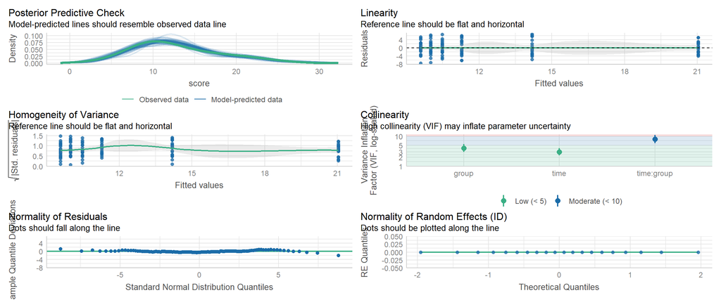

```r
check_model(model)
```

## 9.3 Running the test

Get the inferential statistics using *anova()*

```r
anova(model)
```

```
Type III Analysis of Variance Table with Satterthwaite's method
           Sum Sq Mean Sq NumDF DenDF F value    Pr(>F)
time       733.40  733.40     1   114  63.127 1.519e-12 ***
group      777.58  388.79     2   114  33.465 3.678e-12 ***
time:group 400.57  200.28     2   114  17.239 2.876e-07 ***
---
Signif. codes:  0 '***' 0.001 '**' 0.01 '*' 0.05 '.' 0.1 ' ' 1
```

## 9.4 Post-hoc analysis

**Emmeans**

When there are one or more significant main-effects but no significant interaction effect, post-hoc comparisons can be made for each factor separately.

#### 9.4.0.1 Post-hoc comparison for the first factor

Use the *emmeans()* function, providing the model as first input argument. The second input argument is a formula telling the function to do a pairwise comparison of the different levels of the factor “group” (levels: A, B and C). The resulting output gives:  
1) the estimated means per group level  
2) the pairwise differences and corresponding t-value, degrees of freedom and p-value.

```r
emmeans(object = model, specs = pairwise ~ group)
```

```
$emmeans
 group emmean    SE df lower.CL upper.CL
 A       10.0 0.539 95     8.96     11.1
 B       12.1 0.539 95    11.02     13.2
 C       16.2 0.539 95    15.09     17.2

Results are averaged over the levels of: time
Degrees-of-freedom method: kenward-roger
Confidence level used: 0.95

$contrasts
 contrast estimate    SE df t.ratio p.value
 A - B       -2.06 0.762 95  -2.699  0.0222
 A - C       -6.13 0.762 95  -8.038  <.0001
 B - C       -4.07 0.762 95  -5.339  <.0001

Results are averaged over the levels of: time
Degrees-of-freedom method: kenward-roger
P value adjustment: tukey method for comparing a family of 3 estimates
```

#### 9.4.0.2 Post-hoc comparison for the second factor:

```r
emmeans(object = model, specs = pairwise ~ time)
```

```
$emmeans
 time emmean   SE   df lower.CL upper.CL
 post   15.2 0.44 63.3    14.36     16.1
 pre    10.3 0.44 63.3     9.41     11.2

Results are averaged over the levels of: group
Degrees-of-freedom method: kenward-roger
Confidence level used: 0.95

$contrasts
 contrast   estimate    SE df t.ratio p.value
 post - pre     4.94 0.622 95   7.945  <.0001

Results are averaged over the levels of: group
Degrees-of-freedom method: kenward-roger
```

#### 9.4.0.3 Post-hoc comparison for interaction

When the interaction effect turns out significant, pairwise comparisons can be made between combinations of the factors. One option is a pairwise comparison of all combinations. This is done by using the fomrula “pairwise ~ group * time” as the second input argument.

```r
emmeans(model, pairwise ~ group*time)
```

```
$emmeans
 group time emmean    SE  df lower.CL upper.CL
 A     post  10.48 0.762 114     8.97     12.0
 B     post  14.19 0.762 114    12.68     15.7
 C     post  21.04 0.762 114    19.53     22.5
 A     pre    9.59 0.762 114     8.08     11.1
 B     pre   10.00 0.762 114     8.49     11.5
 C     pre   11.29 0.762 114     9.78     12.8

Degrees-of-freedom method: kenward-roger
Confidence level used: 0.95

$contrasts
 contrast        estimate   SE df t.ratio p.value
 A post - B post   -3.702 1.08 95  -3.435  0.0111
 A post - C post  -10.553 1.08 95  -9.791  <.0001
 A post - A pre     0.897 1.08 95   0.832  0.9608
 A post - B pre     0.484 1.08 95   0.449  0.9976
 A post - C pre    -0.803 1.08 95  -0.745  0.9757
 B post - C post   -6.851 1.08 95  -6.356  <.0001
 B post - A pre     4.599 1.08 95   4.267  0.0007
 B post - B pre     4.186 1.08 95   3.884  0.0026
 B post - C pre     2.899 1.08 95   2.690  0.0868
 C post - A pre    11.450 1.08 95  10.623  <.0001
 C post - B pre    11.037 1.08 95  10.240  <.0001
 C post - C pre     9.750 1.08 95   9.046  <.0001
 A pre - B pre     -0.413 1.08 95  -0.383  0.9989
 A pre - C pre     -1.699 1.08 95  -1.577  0.6158
 B pre - C pre     -1.287 1.08 95  -1.194  0.8389

Degrees-of-freedom method: kenward-roger
P value adjustment: tukey method for comparing a family of 6 estimates
```

However, usually not all comparisons are equally interesting/useful. So another option is to compare between levels of factor 1, within different levels of factor 2. This can be done by providing a simple formula for the first factor (“pairwise ~ time”) and adding a third input argument *by* for the second factor (in this example “group”).

```r
emmeans(object = model, specs = pairwise~time, by="group")
```

```
$emmeans
group = A:
 time emmean    SE  df lower.CL upper.CL
 post  10.48 0.762 114     8.97     12.0
 pre    9.59 0.762 114     8.08     11.1

group = B:
 time emmean    SE  df lower.CL upper.CL
 post  14.19 0.762 114    12.68     15.7
 pre   10.00 0.762 114     8.49     11.5

group = C:
 time emmean    SE  df lower.CL upper.CL
 post  21.04 0.762 114    19.53     22.5
 pre   11.29 0.762 114     9.78     12.8

Degrees-of-freedom method: kenward-roger
Confidence level used: 0.95

$contrasts
group = A:
 contrast   estimate   SE df t.ratio p.value
 post - pre    0.897 1.08 95   0.832  0.4075

group = B:
 contrast   estimate   SE df t.ratio p.value
 post - pre    4.186 1.08 95   3.884  0.0002

group = C:
 contrast   estimate   SE df t.ratio p.value
 post - pre    9.750 1.08 95   9.046  <.0001

Degrees-of-freedom method: kenward-roger
```

This compares the “pre” and “post” levels within each level of “group” (A, B and C). The other way around we can also compare the three levels of “group” within each other per level of “time” using the following code: (Note: by adding $contrasts after the function call we only get the statistical comparisons, and not the means per condition, as they are the same as in the previous call)

```r
emmeans(object = model, specs = pairwise~group, by="time")$contrasts
```

```
time = post:
 contrast estimate   SE df t.ratio p.value
 A - B      -3.702 1.08 95  -3.435  0.0025
 A - C     -10.553 1.08 95  -9.791  <.0001
 B - C      -6.851 1.08 95  -6.356  <.0001

time = pre:
 contrast estimate   SE df t.ratio p.value
 A - B      -0.413 1.08 95  -0.383  0.9224
 A - C      -1.699 1.08 95  -1.577  0.2607
 B - C      -1.287 1.08 95  -1.194  0.4599

Degrees-of-freedom method: kenward-roger
P value adjustment: tukey method for comparing a family of 3 estimates
```

**Pairwise T-tests**

When there are one or more significant main-effects but no significant interaction effect, post-hoc comparisons can be made for each factor separately using the pairwise.t.test() function.

Post-hoc comparison for the first factor:

```r
pairwise.t.test(
  x = data.long$score               # column name of the dependent variable
  ,g = data.long$treatment          # column name of the first within-subjects variable
  , paired = TRUE                   # since it is a paired design, set paired=TRUE
  , p.adjust.method = "bonferroni"  # use bonferroni corrected p-values
  )
```

```
    Pairwise comparisons using paired t tests

data:  data.long$score and data.long$treatment

<0 x 0 matrix>

P value adjustment method: bonferroni
```

Post-hoc comparison for the first factor:

```r
pairwise.t.test(
  x = data.long$score               # column name of the dependent variable
  ,g = data.long$pre_post           # column name of the second within-subjects variable
  , paired = TRUE                   # since it is a paired design, set paired=TRUE
  , p.adjust.method = "bonferroni"  # use bonferroni corrected p-values
  )
```

```
    Pairwise comparisons using paired t tests

data:  data.long$score and data.long$pre_post

<0 x 0 matrix>

P value adjustment method: bonferroni
```

When the interaction effect turns out significant, pairwise comparisons can be made between all combinations of conditions.

Post-hoc comparison for the interaction effect:

```r
pairwise.t.test(
  x = data.long$score               # column name of the dependent variable
  # merge both factor columns into a combined factor
  ,g = paste(data.long$treatment, data.long$pre_post)
  , paired = TRUE                   # since it is a paired design, set paired=TRUE
  , p.adjust.method = "bonferroni"  # use bonferroni corrected p-values
  )
```

```
    Pairwise comparisons using paired t tests

data:  data.long$score and paste(data.long$treatment, data.long$pre_post)

<0 x 0 matrix>

P value adjustment method: bonferroni
```

## 9.5 Visualisation

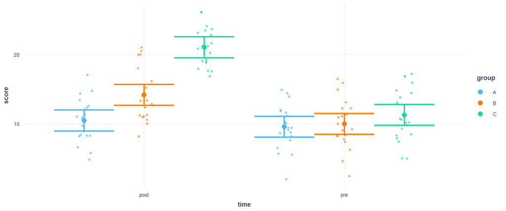

```r
cat_plot(model = model,
         pred = time,
         modx = group,
         interval = TRUE,
         plot.points = TRUE,
         jitter = 0.2)
```

# 10 Mixed-Design ANOVA

**Show code for data generation**

```r
set.seed(02)   # set seed
nrofcondsf1 = 3  # set number of conditions for factor 1
nrofcondsf2 = 2  # set number of conditions for factor 2
nrofsubs    = 30 # set number of subjects per condition
subj = as.factor(rep(x= 1:(nrofsubs*nrofcondsf2), times=nrofcondsf1))       # create array with subject IDs
# create array witht treatment conditions
treatment = as.factor(rep(LETTERS[1:nrofcondsf1],each=nrofsubs*nrofcondsf2))
# create array with control / experimental
gender   = as.factor(rep(c("men","women"),times=nrofsubs*nrofcondsf1))
# create array with measurement values
score = as.vector( replicate(nrofcondsf1, replicate (
          nrofcondsf2 , rnorm(
            n = (nrofsubs),
            mean = 0 , sd = sample(3,1)+2 ) + sample(8,1)+10
        ) ) )
# combine arrays into a data.frame
data.long = data.frame(subj, score, treatment, gender);
# delete unnecessary arrays
# rm(list=c("gender","nrofcondsf1","nrofcondsf2","nrofsubs","score","subj","treatment"))
```

data.long

| subj | score | treatment | gender |
| --- | --- | --- | --- |
| 1 | 13.593722 | A | men |
| 2 | 9.114324 | A | women |
| 1 | 12.451104 | B | men |
| 2 | 12.882231 | B | women |
| 1 | 6.844534 | C | men |
| 2 | 3.979478 | C | women |

**Using lmer() (PB recommended)**

### 10.0.1 Fitting the model

Here we use the same code as with a factorial repeated measures ANOVA to fit the model:

```r
model = lmerTest::lmer(
  formula = score~treatment*gender + (1|subj),
  data = data.long)
```

### 10.0.2 Checking assumptions

Then we can inspect the assumptions of the model:

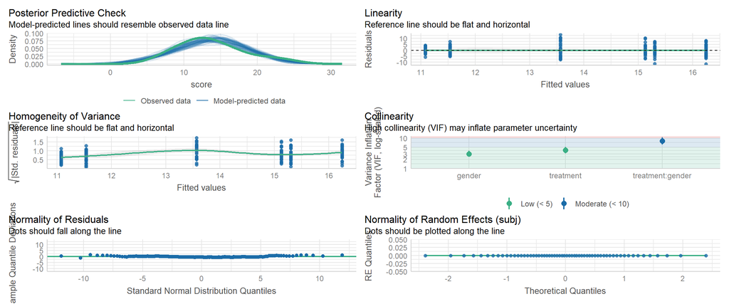

```r
check_model(model)
```

### 10.0.3 Running the test

Then we can get the inferential statistics on both main effects and the interaction effect.

```r
anova(model)
```

```
Type III Analysis of Variance Table with Satterthwaite's method
                 Sum Sq Mean Sq NumDF DenDF F value    Pr(>F)
treatment        611.56 305.781     2   174 16.0571 3.985e-07 ***
gender            28.86  28.856     1   174  1.5153    0.2200
treatment:gender  38.37  19.184     2   174  1.0074    0.3673
---
Signif. codes:  0 '***' 0.001 '**' 0.01 '*' 0.05 '.' 0.1 ' ' 1
```

### 10.0.4 Post-hoc analysis

When there are significant main effects but no significant interaction effect we can inspect the post-hoc comparisons within each factor:

```r
emmeans(object = model, specs = pairwise~treatment)

emmeans(object = model, specs = pairwise~gender)
```

```
$emmeans
 treatment emmean    SE  df lower.CL upper.CL
 A           11.3 0.563 174     10.2     12.4
 B           15.7 0.563 174     14.6     16.8
 C           14.4 0.563 174     13.3     15.5

Results are averaged over the levels of: gender
Degrees-of-freedom method: kenward-roger
Confidence level used: 0.95

$contrasts
 contrast estimate    SE  df t.ratio p.value
 A - B       -4.38 0.797 116  -5.502  <.0001
 A - C       -3.13 0.797 116  -3.928  0.0004
 B - C        1.25 0.797 116   1.574  0.2611

Results are averaged over the levels of: gender
Degrees-of-freedom method: kenward-roger
P value adjustment: tukey method for comparing a family of 3 estimates

$emmeans
 gender emmean   SE df lower.CL upper.CL
 men      13.4 0.46 58     12.5     14.3
 women    14.2 0.46 58     13.3     15.1

Results are averaged over the levels of: treatment
Degrees-of-freedom method: kenward-roger
Confidence level used: 0.95

$contrasts
 contrast    estimate    SE df t.ratio p.value
 men - women   -0.801 0.651 58  -1.231  0.2233

Results are averaged over the levels of: treatment
Degrees-of-freedom method: kenward-roger
```

When there is a significant interaction effect it is more relevant to inspect the combinations of factors:

```r
emmeans(object=model, specs=pairwise~treatment, by="gender")
emmeans(object=model, specs=pairwise~gender, by="treatment")$contrasts
```

```
$emmeans
gender = men:
 treatment emmean    SE  df lower.CL upper.CL
 A           11.5 0.797 174     9.96     13.1
 B           15.1 0.797 174    13.55     16.7
 C           13.6 0.797 174    11.99     15.1

gender = women:
 treatment emmean    SE  df lower.CL upper.CL
 A           11.1 0.797 174     9.50     12.6
 B           16.2 0.797 174    14.67     17.8
 C           15.3 0.797 174    13.73     16.9

Degrees-of-freedom method: kenward-roger
Confidence level used: 0.95

$contrasts
gender = men:
 contrast estimate   SE  df t.ratio p.value
 A - B      -3.595 1.13 116  -3.191  0.0052
 A - C      -2.033 1.13 116  -1.804  0.1727
 B - C       1.562 1.13 116   1.386  0.3514

gender = women:
 contrast estimate   SE  df t.ratio p.value
 A - B      -5.171 1.13 116  -4.590  <.0001
 A - C      -4.226 1.13 116  -3.751  0.0008
 B - C       0.946 1.13 116   0.839  0.6795

Degrees-of-freedom method: kenward-roger
P value adjustment: tukey method for comparing a family of 3 estimates

treatment = A:
 contrast    estimate   SE  df t.ratio p.value
 men - women    0.456 1.13 174   0.404  0.6864

treatment = B:
 contrast    estimate   SE  df t.ratio p.value
 men - women   -1.121 1.13 174  -0.995  0.3212

treatment = C:
 contrast    estimate   SE  df t.ratio p.value
 men - women   -1.737 1.13 174  -1.542  0.1249

Degrees-of-freedom method: kenward-roger
```

**Using ezANOVA()**

Fit mixed-model using ezANOVA() function

```r
mix.model = ezANOVA(data = data.long      # name of the data frame (long format)
                    , dv = score          # column name of the dependent variabele
                    , wid = subj          # column name indicating subject ID
                    , within = treatment  # column name of the within factor
                    , between = gender    # column name of the between factor
                    , return_aov = TRUE   # add information to the output for normality testing
                    )
```

### 10.0.5 Checking assumptions

Test assumption of normality of the residuals

```r
shapiro.test(mix.model$aov$`subj:treatment`$residuals)

hist(mix.model$aov$`subj:treatment`$residuals
     , xlab = 'Residuals'
     , main = 'Histogram of residuals')
```

```
    Shapiro-Wilk normality test

data:  mix.model$aov$`subj:treatment`$residuals
W = 0.96986, p-value = 0.008531
```

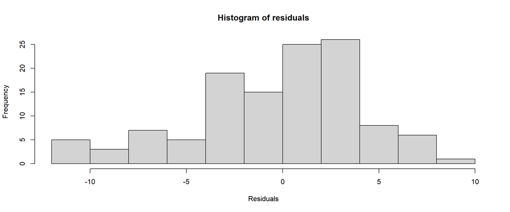

Test assumption of sphericity

```r
mix.model$`Mauchly's Test for Sphericity`
```

```
            Effect         W            p p<.05
3        treatment 0.7396107 0.0001847524     *
4 gender:treatment 0.7396107 0.0001847524     *
```

### 10.0.6 Running the test

If the assumption of sphericity is met use the normal, uncorrected ANOVA output

```r
mix.model$ANOVA
```

```
            Effect DFn DFd         F            p p<.05         ges
2           gender   1  58  1.732189 1.933095e-01       0.008633356
3        treatment   2 116 15.111036 1.471679e-06     * 0.155808066
4 gender:treatment   2 116  0.948039 3.904817e-01       0.011446712
```

If the assumption of sphericity is violated, use the corrected ANOVA output (The Greenhouse-Geisser correction is more conservative than the Huynd-Feldt correction)

```r
mix.model$`Sphericity Corrections`
```

```
            Effect       GGe        p[GG] p[GG]<.05       HFe        p[HF]
3        treatment 0.7934056 1.242358e-05         * 0.8120607 1.024174e-05
4 gender:treatment 0.7934056 3.728473e-01           0.8120607 3.746703e-01
  p[HF]<.05
3         *
4
```

### 10.0.7 Post-hoc analysis

When there are one or more significant main-effects but no significant interaction effect post-hoc comparisons can be made using the pairwise.t.test() function.

Post-hoc comparison for the between-subjects factor:

```r
pairwise.t.test(
  x=data.long$score               # column name of the dependent variable
, g=data.long$gender              # column name of the independent between-subjects variable
, paired = TRUE                   # for the within factor, set paired=TRUE
, p.adjust.method = 'bonferroni'  # use bonferroni corrected p-values
)
```

```
    Pairwise comparisons using paired t tests

data:  data.long$score and data.long$gender

      men
women 0.14

P value adjustment method: bonferroni
```

Post-hoc comparison for the within-subjects factor:

```r
pairwise.t.test(
  x=data.long$score               # column name of the dependent variable
, g=data.long$treatment           # column name of the independent within-subjects variable
, paired = TRUE                   # for the within factor, set paired=TRUE
, p.adjust.method = 'bonferroni'  # use bonferroni corrected p-values
)
```

```
    Pairwise comparisons using paired t tests

data:  data.long$score and data.long$treatment

  A       B
B 4.4e-09 -
C 0.0012  0.6116

P value adjustment method: bonferroni
```

When the interaction-effect turns out significant, pairwise comparisons within each factor are not very informative about what the interaction looks like. Pairwise t-tests between all combinations of conditions is inappropriate when dealing with mixed designs. The best way to interpret an interaction effect is by looking at the interaction pattern in the data using descriptive statistics and visualization.

## 10.1 Visualisation

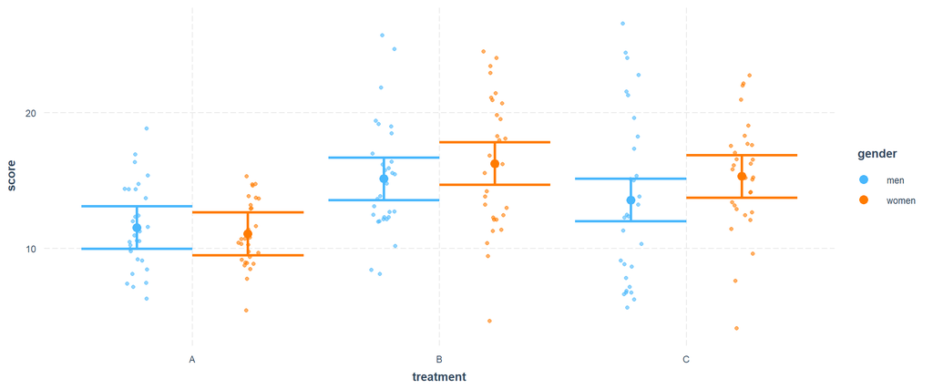

```r
cat_plot(model = model,
              pred = treatment,
              modx = gender,
              plot.points = TRUE,
              interval = TRUE,
              jitter = 0.2)
```